# Ocena poziomu otyłości na podstawie nawyków

## Streszczenie:

W pracy przedstawiono dane umożliwiające ocenę poziomu otyłości u osób z krajów Meksyku, Peru i Kolumbii na podstawie ich nawyków żywieniowych i kondycji fizycznej. Dane zawierają 17 atrybutów i 2111 rekordów, rekordy są oznaczone zmienną klasową NObesity (Poziom otyłości), która pozwala na klasyfikację danych za pomocą wartości Niewystarczająca waga, Normalna waga, Nadwaga poziomu I, Nadwaga poziomu II, Otyłość typu I , Otyłość typu II i Otyłość typu III. 77% danych wygenerowano syntetycznie przy użyciu narzędzia Weka i filtra SMOTE, 23% danych zebrano bezpośrednio od użytkowników za pośrednictwem platformy internetowej. Dane te można wykorzystać do wygenerowania inteligentnych narzędzi obliczeniowych do identyfikacji poziomu otyłości danej osoby oraz do zbudowania systemów rekomendacyjnych monitorujących poziom otyłości. Dyskusję i więcej informacji na temat tworzenia zbioru danych można znaleźć w pełnym artykule "Obesity Level Estimation Software based on Decision Trees" (De-La-Hoz-Correa et al., 2019).

## Słowa kluczowe:

Otyłość, analiza danych, klasteryzacja, k-mean clusters, ward clusters

## Wprowadzenie:

Otyłość jest rosnącym problemem zdrowotnym na całym świecie, mającym poważne konsekwencje dla zdrowia publicznego. W krajach Ameryki Łacińskiej, takich jak Meksyk, Peru i Kolumbia, problem ten staje się coraz bardziej wyraźny, wpływając na jakość życia milionów ludzi. Zrozumienie nawyków żywieniowych i kondycji fizycznej jest kluczowe w ocenie poziomu otyłości oraz w opracowywaniu skutecznych strategii interwencji. W niniejszej pracy zaprezentowano dane, które umożliwiają ocenę poziomu otyłości na podstawie nawyków żywieniowych i aktywności fizycznej, co może przyczynić się do lepszego zrozumienia tego zjawiska i pomóc w rozwoju narzędzi monitorujących stan zdrowia.

# Przedmiot badania:

# Cel i zakres badania:

- Celem badania jest pogrupowania naszych danych na grupy okreslające otyłość osoby. Do tego badania użyjemy metody k-średnich oraz Warda.

# Przegląd literatury:

- 1. Palechor FM, Manotas AH. Dataset for estimation of obesity levels based on eating habits and physical condition in individuals from Colombia, Peru and Mexico. Data Brief. 2019 Aug 2;25:104344. doi: 10.1016/j.dib.2019.104344. PMID: 31467953; PMCID: PMC6710633. https://pubmed.ncbi.nlm.nih.gov/31467953/  
     Artykuł przedstawia dane do oceny poziomu otyłości u osób z Meksyku, Peru i Kolumbii, uwzględniając ich nawyki żywieniowe i kondycję fizyczną. Zbiór danych zawiera 17 atrybutów i 2111 rekordów, sklasyfikowanych według poziomu otyłości: od niedowagi do otyłości typu III. 77% danych wygenerowano syntetycznie, a 23% pochodziło bezpośrednio od użytkowników platformy internetowej.
  2. Derouiche, Abderrahim et al. “Meal-taking activity monitoring in the elderly based on sensor data: Comparison of unsupervised classification methods.” ArXiv abs/2409.02971 (2024): n. pag. https://www.semanticscholar.org/reader/a64b98c0a17505627dc63989d046713c71ef063d  
     W badaniu analizowano dane dotyczące aktywności związanej z przyjmowaniem posiłków, pochodzące z czterech gospodarstw domowych wyposażonych w czujniki. Do klasteryzacji tych danych wykorzystano trzy algorytmy: K-Means, GMM oraz DBSCAN. Następnie, za pomocą indeksu Daviesa-Bouldina (DBI) oceniano jakość klastrów generowanych przez każdy z algorytmów.
  3. Helforoush Z, Sayyad H. Prediction and classification of obesity risk based on a hybrid metaheuristic machine learning approach. Front Big Data. 2024 Sep 30;7:1469981. doi: 10.3389/fdata.2024.1469981. PMID: 39403430; PMCID: PMC11471553. https://pubmed.ncbi.nlm.nih.gov/39403430/  
     W badaniu przeanalizowano zjawisko otyłości jako istotnego problemu zdrowia publicznego i jego wpływ na zdrowie oraz gospodarkę. Wykorzystano siedem różnych algorytmów uczenia maszynowego (m.in. Logistic Regression, Random Forest, SVM, LGBM, XGBoost, CATBoost, MLP) oraz nowy model hybrydowy ANN-PSO (Artificial Neural Networks-Particle Swarm Optimization) w celu dokładnego przewidywania ryzyka otyłości. Model ANN-PSO, łączący sieci neuronowe i optymalizację rojem cząsteczek, osiągnął lepsze wyniki w zakresie precyzji i skuteczności w porównaniu z tradycyjnymi algorytmami, wskazując na potencjał tej metody w analizie predykcyjnej otyłości.
  4. Kędra M. Analiza skupień w piłce nożnej https://rpubs.com/mkedra/550910  
     W badaniu przeanalizowana czołowych piłkarzy , aby ich przypisać na odpowiednie pozycję boiskowe, na podstawie ich statystyk.
  5. Kowalczyk Z. Clustering on Obesity Data https://rpubs.com/ztk_99/1143926  
     W badaniu były analizowane nasze dane. Zastosowane były metody klasteryzacji k-średnich, Warda oraz PAM.

```python
import pandas as pd
import numpy as np
import matplotlib.pyplot as plt
import seaborn as sns

from sklearn.preprocessing import LabelEncoder
from sklearn.preprocessing import StandardScaler, MinMaxScaler
from sklearn.cluster import KMeans, AgglomerativeClustering
from sklearn.metrics import adjusted_rand_score, silhouette_score
from sklearn.metrics import pairwise_distances

import warnings
warnings.filterwarnings("ignore")
```

# Import danych:

```python
df = pd.read_excel('dane.xlsx')
```

| Zmienna | Rola | Typ | Opis |
| --- | --- | --- | --- |
| Gender | Cecha | Kategoryczna | Płeć |
| Age | Cecha | Ciągła | Wiek |
| Height | Cecha | Ciągła | Wzrost |
| Weight | Cecha | Ciągła | Waga |
| family_history_with_overweight | Cecha | Binarny | Czy członek rodziny cierpiał lub cierpi na nadwagę? |
| FAVC | Cecha | Binarny | Czy często spożywasz wysokokaloryczne jedzenie? |
| FCVC | Cecha | Ciągła | Czy zazwyczaj jesz warzywa podczas posiłków? |
| NCP | Cecha | Ciągła | Ile posiłków głównych spożywasz dziennie? |
| CAEC | Cecha | Kategoryczna | Czy spożywasz jedzenie między posiłkami? |
| SMOKE | Cecha | Binarny | Czy palisz papierosy? |
| CH2O | Cecha | Ciągła | Ile wody pijesz codziennie? |
| SCC | Cecha | Binarny | Czy monitorujesz spożycie kalorii codziennie? |
| FAF | Cecha | Ciągła | Ile razy w ciągu tygodnia angażujesz się w aktywność fizyczną? |
| TUE | Cecha | Ciągła | Ile czasu spędzasz korzystając z urządzeń technologicznych, takich jak telefon, gry, telewizor, itp.? |
| CALC | Cecha | Kategoryczna | Jak często pijesz alkohol? |
| MTRANS | Cecha | Kategoryczna | Jakiego środka transportu najczęściej używasz? |
| NObeyesdad | Cel | Kategoryczna | Poziom otyłości |

# Sprawdzenie danych

```python
df.head()
```

|  | Gender | Age | Height | Weight | family_history_with_overweight | FAVC | FCVC | NCP | CAEC | SMOKE | CH2O | SCC | FAF | TUE | CALC | MTRANS | NObeyesdad |
| --- | --- | --- | --- | --- | --- | --- | --- | --- | --- | --- | --- | --- | --- | --- | --- | --- | --- |
| 0 | Female | 21.0 | 1.62 | 64.0 | yes | no | 2.0 | 3.0 | Sometimes | no | 2.0 | no | 0.0 | 1.0 | no | Public_Transportation | Normal_Weight |
| 1 | Female | 21.0 | 1.52 | 56.0 | yes | no | 3.0 | 3.0 | Sometimes | yes | 3.0 | yes | 3.0 | 0.0 | Sometimes | Public_Transportation | Normal_Weight |
| 2 | Male | 23.0 | 1.80 | 77.0 | yes | no | 2.0 | 3.0 | Sometimes | no | 2.0 | no | 2.0 | 1.0 | Frequently | Public_Transportation | Normal_Weight |
| 3 | Male | 27.0 | 1.80 | 87.0 | no | no | 3.0 | 3.0 | Sometimes | no | 2.0 | no | 2.0 | 0.0 | Frequently | Walking | Overweight_Level_I |
| 4 | Male | 22.0 | 1.78 | 89.8 | no | no | 2.0 | 1.0 | Sometimes | no | 2.0 | no | 0.0 | 0.0 | Sometimes | Public_Transportation | Overweight_Level_II |

```python
df.info()
```

```
<class 'pandas.core.frame.DataFrame'>
RangeIndex: 2111 entries, 0 to 2110
Data columns (total 17 columns):
 #   Column                          Non-Null Count  Dtype
---  ------                          --------------  -----
 0   Gender                          2111 non-null   object
 1   Age                             2111 non-null   float64
 2   Height                          2111 non-null   float64
 3   Weight                          2111 non-null   float64
 4   family_history_with_overweight  2111 non-null   object
 5   FAVC                            2111 non-null   object
 6   FCVC                            2111 non-null   float64
 7   NCP                             2111 non-null   float64
 8   CAEC                            2111 non-null   object
 9   SMOKE                           2111 non-null   object
 10  CH2O                            2111 non-null   float64
 11  SCC                             2111 non-null   object
 12  FAF                             2111 non-null   float64
 13  TUE                             2111 non-null   float64
 14  CALC                            2111 non-null   object
 15  MTRANS                          2111 non-null   object
 16  NObeyesdad                      2111 non-null   object
dtypes: float64(8), object(9)
memory usage: 280.5+ KB
```

```python
df.isnull().sum()
```

```
Gender                            0
Age                               0
Height                            0
Weight                            0
family_history_with_overweight    0
FAVC                              0
FCVC                              0
NCP                               0
CAEC                              0
SMOKE                             0
CH2O                              0
SCC                               0
FAF                               0
TUE                               0
CALC                              0
MTRANS                            0
NObeyesdad                        0
dtype: int64
```

# Statystyka opisowe:

```python
df.describe()
```

|  | Age | Height | Weight | FCVC | NCP | CH2O | FAF | TUE |
| --- | --- | --- | --- | --- | --- | --- | --- | --- |
| count | 2111.000000 | 2111.000000 | 2111.000000 | 2111.000000 | 2111.000000 | 2111.000000 | 2111.000000 | 2111.000000 |
| mean | 24.312600 | 1.701677 | 86.586058 | 2.419043 | 2.685628 | 2.008011 | 1.010298 | 0.657866 |
| std | 6.345968 | 0.093305 | 26.191172 | 0.533927 | 0.778039 | 0.612953 | 0.850592 | 0.608927 |
| min | 14.000000 | 1.450000 | 39.000000 | 1.000000 | 1.000000 | 1.000000 | 0.000000 | 0.000000 |
| 25% | 19.947192 | 1.630000 | 65.473343 | 2.000000 | 2.658738 | 1.584812 | 0.124505 | 0.000000 |
| 50% | 22.777890 | 1.700499 | 83.000000 | 2.385502 | 3.000000 | 2.000000 | 1.000000 | 0.625350 |
| 75% | 26.000000 | 1.768464 | 107.430682 | 3.000000 | 3.000000 | 2.477420 | 1.666678 | 1.000000 |
| max | 61.000000 | 1.980000 | 173.000000 | 3.000000 | 4.000000 | 3.000000 | 3.000000 | 2.000000 |

```python
df.describe(include='object')
```

|  | Gender | family_history_with_overweight | FAVC | CAEC | SMOKE | SCC | CALC | MTRANS | NObeyesdad |
| --- | --- | --- | --- | --- | --- | --- | --- | --- | --- |
| count | 2111 | 2111 | 2111 | 2111 | 2111 | 2111 | 2111 | 2111 | 2111 |
| unique | 2 | 2 | 2 | 4 | 2 | 2 | 4 | 5 | 7 |
| top | Male | yes | yes | Sometimes | no | no | Sometimes | Public_Transportation | Obesity_Type_I |
| freq | 1068 | 1726 | 1866 | 1765 | 2067 | 2015 | 1401 | 1580 | 351 |

```python
df['Age'] = df['Age'].apply(lambda age : round(age))
df['Height'] = df['Height'].apply(lambda height : round(100*height))
df['Weight'] = df['Weight'].apply(lambda weight : round(weight))
df['FCVC'] = df['FCVC'].apply(lambda fcvc : round(fcvc))
df['NCP'] = df['NCP'].apply(lambda ncp : round(ncp))
df['CH2O'] = df['CH2O'].apply(lambda ch2o : round(ch2o))
df['FAF'] = df['FAF'].apply(lambda faf : round(faf))
df['TUE'] = df['TUE'].apply(lambda tue : round(tue))
```

```python
df.info()
#lista zmienncyh do wywalenia z uwagi na brak sesnu
df_object = df.select_dtypes(include='object')
df_int = df.select_dtypes(include='int64')
df_object.info()
df_int.info()
```

```
<class 'pandas.core.frame.DataFrame'>
RangeIndex: 2111 entries, 0 to 2110
Data columns (total 17 columns):
 #   Column                          Non-Null Count  Dtype
---  ------                          --------------  -----
 0   Gender                          2111 non-null   object
 1   Age                             2111 non-null   int64
 2   Height                          2111 non-null   int64
 3   Weight                          2111 non-null   int64
 4   family_history_with_overweight  2111 non-null   object
 5   FAVC                            2111 non-null   object
 6   FCVC                            2111 non-null   int64
 7   NCP                             2111 non-null   int64
 8   CAEC                            2111 non-null   object
 9   SMOKE                           2111 non-null   object
 10  CH2O                            2111 non-null   int64
 11  SCC                             2111 non-null   object
 12  FAF                             2111 non-null   int64
 13  TUE                             2111 non-null   int64
 14  CALC                            2111 non-null   object
 15  MTRANS                          2111 non-null   object
 16  NObeyesdad                      2111 non-null   object
dtypes: int64(8), object(9)
memory usage: 280.5+ KB
<class 'pandas.core.frame.DataFrame'>
RangeIndex: 2111 entries, 0 to 2110
Data columns (total 9 columns):
 #   Column                          Non-Null Count  Dtype
---  ------                          --------------  -----
 0   Gender                          2111 non-null   object
 1   family_history_with_overweight  2111 non-null   object
 2   FAVC                            2111 non-null   object
 3   CAEC                            2111 non-null   object
 4   SMOKE                           2111 non-null   object
 5   SCC                             2111 non-null   object
 6   CALC                            2111 non-null   object
 7   MTRANS                          2111 non-null   object
 8   NObeyesdad                      2111 non-null   object
dtypes: object(9)
memory usage: 148.6+ KB
<class 'pandas.core.frame.DataFrame'>
RangeIndex: 2111 entries, 0 to 2110
Data columns (total 8 columns):
 #   Column  Non-Null Count  Dtype
---  ------  --------------  -----
 0   Age     2111 non-null   int64
 1   Height  2111 non-null   int64
 2   Weight  2111 non-null   int64
 3   FCVC    2111 non-null   int64
 4   NCP     2111 non-null   int64
 5   CH2O    2111 non-null   int64
 6   FAF     2111 non-null   int64
 7   TUE     2111 non-null   int64
dtypes: int64(8)
memory usage: 132.1 KB
```

# Podstawowa wizualizacja :

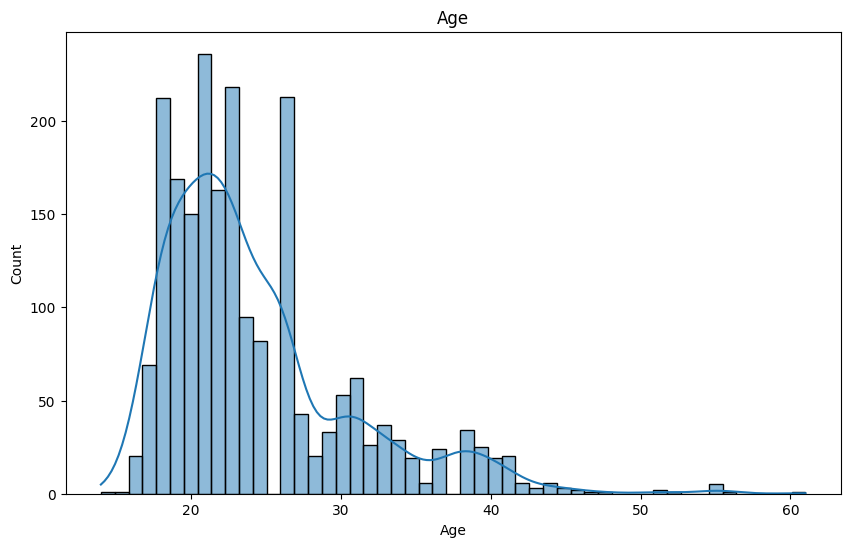

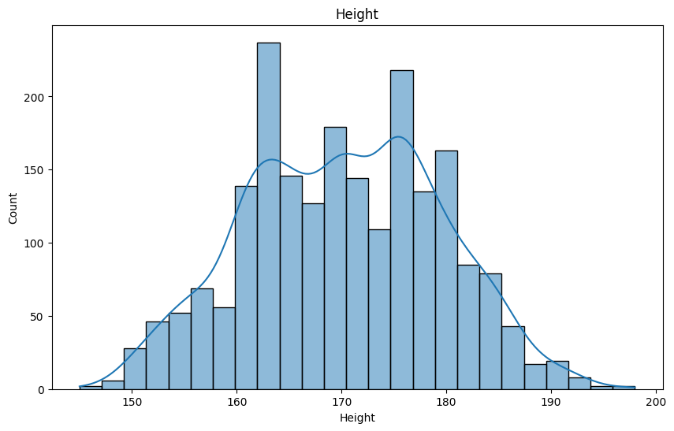

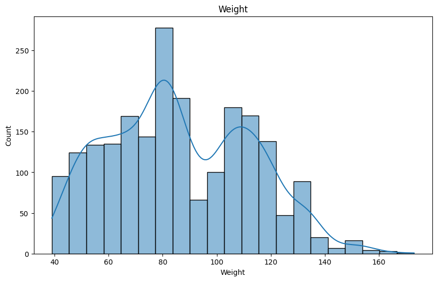

```python
df_hist = df_int[['Age', 'Height', 'Weight']]
float_names = df_hist.columns
for i in float_names:
    plt.figure(figsize=(10, 6))
    plt.title(i)
    sns.histplot(x=df_hist[i], kde=True)
    plt.show()
```

```python
df_int_to_obj = df_int[['FCVC', 'NCP', 'CH2O', 'FAF', 'TUE']]

mapping1 = {1:'Never', 2:'Sometimes', 3:'Always'}
mapping2 = {1: '1', 2:'2' , 3: '3', 4: '3+'}
mapping3 = {1: 'Less than a liter', 2:'Between 1 and 2 L', 3:'More than 2 L'}
mapping4 = {0: 'I do not have', 1: '1 or 2 days', 2: '2 or 4 days', 3: '4 or 5 days'}
mapping5 = {0: '0–2 hours', 1: '3–5 hours', 2: 'More than 5 hours'}

df_int_to_obj['FCVC'] = df_int_to_obj['FCVC'].replace(mapping1)
df_int_to_obj['NCP'] = df_int_to_obj['NCP'].replace(mapping2)
df_int_to_obj['CH2O'] = df_int_to_obj['CH2O'].replace(mapping3)
df_int_to_obj['FAF'] = df_int_to_obj['FAF'].replace(mapping4)
df_int_to_obj['TUE'] = df_int_to_obj['TUE'].replace(mapping5)
```

[figure not shown]

```python
plt.figure(figsize=(18, 20))
sns.set_palette("bright")

df_obj_int_cat = pd.concat([df_object,df_int_to_obj])
object_names = df_obj_int_cat.columns

for i, column in enumerate(object_names, 1):
    plt.subplot(5, 3, i)
    sns.countplot(x=df_obj_int_cat[column], order=df_obj_int_cat[column].value_counts().index)
    plt.title(column)
    plt.xlabel("")
    plt.ylabel("")
    plt.tight_layout()
    plt.xticks(rotation=45, ha='right')

plt.show()
```

```python
zmienne_cat = df_object.columns
zmienne_cat_minusY = zmienne_cat[:len(zmienne_cat)-1]
df_object_encoded = df_object.copy()
le = LabelEncoder()

for col in zmienne_cat_minusY:
    df_object_encoded[col] = le.fit_transform(df_object[col])

category_mapping = {
    'Insufficient_Weight': 0,
    'Normal_Weight': 1,
    'Overweight_Level_I': 2,
    'Overweight_Level_II': 3,
    'Obesity_Type_I': 4,
    'Obesity_Type_II': 5,
    'Obesity_Type_III': 6
}
df_object_encoded['NObeyesdad'] = df_object_encoded['NObeyesdad'].map(category_mapping)

df_object_encoded = df_object_encoded.astype('int64')
for i in zmienne_cat:
    print(df_object[i].value_counts())
    print(df_object_encoded[i].value_counts())
df_object_encoded.head()
```

```
Gender
Male      1068
Female    1043
Name: count, dtype: int64
Gender
1    1068
0    1043
Name: count, dtype: int64
family_history_with_overweight
yes    1726
no      385
Name: count, dtype: int64
family_history_with_overweight
1    1726
0     385
Name: count, dtype: int64
FAVC
yes    1866
no      245
Name: count, dtype: int64
FAVC
1    1866
0     245
Name: count, dtype: int64
CAEC
Sometimes     1765
Frequently     242
Always          53
no              51
Name: count, dtype: int64
CAEC
2    1765
1     242
0      53
3      51
Name: count, dtype: int64
SMOKE
no     2067
yes      44
Name: count, dtype: int64
```

[output cut: 41 more lines]

```
Obesity_Type_II        297
Overweight_Level_I     290
Overweight_Level_II    290
Normal_Weight          287
Insufficient_Weight    272
Name: count, dtype: int64
NObeyesdad
4    351
6    324
5    297
2    290
3    290
1    287
0    272
Name: count, dtype: int64
```

|  | Gender | family_history_with_overweight | FAVC | CAEC | SMOKE | SCC | CALC | MTRANS | NObeyesdad |
| --- | --- | --- | --- | --- | --- | --- | --- | --- | --- |
| 0 | 0 | 1 | 0 | 2 | 0 | 0 | 3 | 3 | 1 |
| 1 | 0 | 1 | 0 | 2 | 1 | 1 | 2 | 3 | 1 |
| 2 | 1 | 1 | 0 | 2 | 0 | 0 | 1 | 3 | 1 |
| 3 | 1 | 0 | 0 | 2 | 0 | 0 | 1 | 4 | 2 |
| 4 | 1 | 0 | 0 | 2 | 0 | 0 | 2 | 3 | 3 |

```python
DF = pd.concat([df_int,df_object_encoded], axis=1)
X = DF.iloc[:, :-1]
y = DF['NObeyesdad']
```

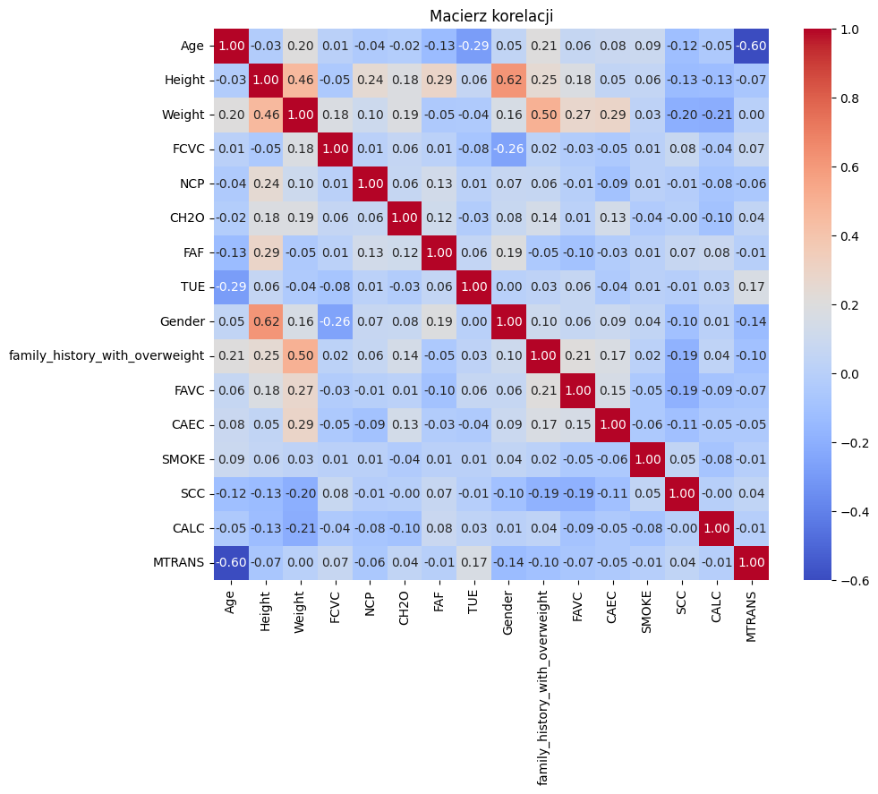

```python
corr = X.corr()
plt.figure(figsize=(10, 8))
sns.heatmap(corr, annot=True, cmap='coolwarm', fmt='.2f')
plt.title('Macierz korelacji')
plt.show()
```

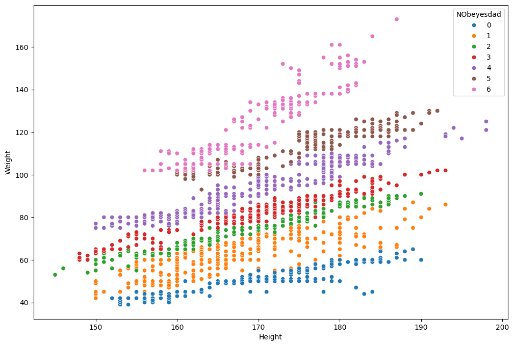

```python
# Wiek i wzrost, a otyłość
plt.figure(figsize=(12,8))
sns.scatterplot(x='Height', y='Weight',data=DF, palette= 'tab10', hue = 'NObeyesdad')
plt.show()
```

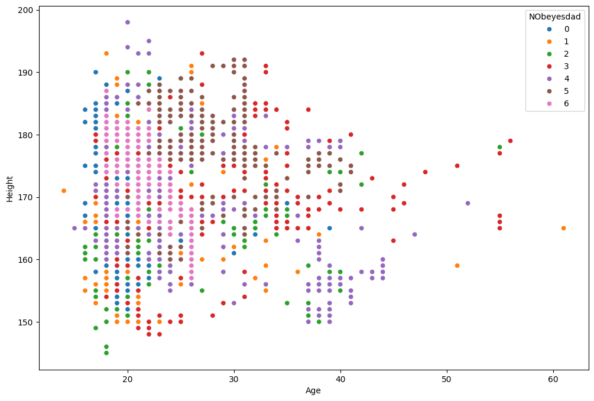

```python
# Wiek i waga, a otyłość
plt.figure(figsize=(12,8))
sns.scatterplot(x='Age', y='Height',data=DF, palette= 'tab10', hue = 'NObeyesdad')
plt.show()
```

# Obserwacje odstające:

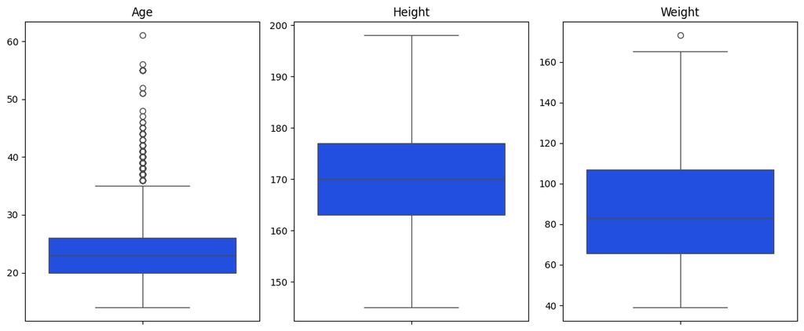

```python
to_check = ['Age', 'Height', 'Weight']
X_2 = X[to_check]

plt.figure(figsize=(12, 5))
for i, column in enumerate(X_2.columns, 1):
    plt.subplot(1, 3, i)
    sns.boxplot(y=DF[column])
    plt.title(f'{column}')
    plt.ylabel('')
plt.tight_layout()
plt.show()
```

```python
Q1 = X_2.quantile(0.25)
Q3 = X_2.quantile(0.75)
IQR = Q3 - Q1

lower_bound = Q1 - 1.5 * IQR
upper_bound = Q3 + 1.5 * IQR

outliers = ((X_2 < lower_bound) | (X_2 > upper_bound))

outliers_count = outliers.sum()
print("Liczba odstających wartości w każdej kolumnie:")
print(outliers_count)
```

```
Liczba odstających wartości w każdej kolumnie:
Age       160
Height      0
Weight      1
dtype: int64
```

```python
for col in X_2.columns:
    print(f"\nZmienne odstające w kolumnie {col}:\n")
    outliers_in_col = DF[outliers[col]]
    if outliers_in_col.empty == False:
        display(outliers_in_col)
    else:
        print("Brak wartości odstających.")
DF.info()
```

```
Zmienne odstające w kolumnie Age:
```

|  | Age | Height | Weight | FCVC | NCP | CH2O | FAF | TUE | Gender | family_history_with_overweight | FAVC | CAEC | SMOKE | SCC | CALC | MTRANS | NObeyesdad |
| --- | --- | --- | --- | --- | --- | --- | --- | --- | --- | --- | --- | --- | --- | --- | --- | --- | --- |
| 13 | 41 | 180 | 99 | 2 | 3 | 2 | 2 | 1 | 1 | 0 | 1 | 2 | 0 | 0 | 1 | 0 | 4 |
| 21 | 52 | 169 | 87 | 3 | 1 | 2 | 0 | 0 | 0 | 1 | 1 | 2 | 1 | 0 | 3 | 0 | 4 |
| 33 | 39 | 179 | 90 | 2 | 1 | 2 | 0 | 0 | 1 | 0 | 0 | 2 | 0 | 0 | 2 | 3 | 3 |
| 92 | 55 | 178 | 84 | 3 | 4 | 3 | 3 | 0 | 1 | 1 | 0 | 1 | 0 | 1 | 1 | 4 | 2 |
| 104 | 38 | 156 | 80 | 2 | 3 | 2 | 0 | 0 | 0 | 1 | 1 | 2 | 0 | 0 | 2 | 0 | 4 |
| ... | ... | ... | ... | ... | ... | ... | ... | ... | ... | ... | ... | ... | ... | ... | ... | ... | ... |
| 1740 | 38 | 176 | 118 | 2 | 3 | 2 | 1 | 0 | 1 | 1 | 1 | 2 | 0 | 0 | 2 | 0 | 5 |
| 1775 | 37 | 176 | 118 | 2 | 3 | 2 | 1 | 0 | 1 | 1 | 1 | 2 | 0 | 0 | 2 | 0 | 5 |
| 1776 | 38 | 175 | 119 | 2 | 3 | 2 | 1 | 1 | 1 | 1 | 1 | 2 | 0 | 0 | 2 | 0 | 5 |
| 1777 | 39 | 177 | 118 | 2 | 3 | 2 | 1 | 0 | 1 | 1 | 1 | 2 | 0 | 0 | 2 | 0 | 5 |
| 1778 | 38 | 177 | 118 | 2 | 3 | 2 | 1 | 0 | 1 | 1 | 1 | 2 | 0 | 0 | 2 | 0 | 5 |

160 rows × 17 columns

```
Zmienne odstające w kolumnie Height:

Brak wartości odstających.

Zmienne odstające w kolumnie Weight:
```

|  | Age | Height | Weight | FCVC | NCP | CH2O | FAF | TUE | Gender | family_history_with_overweight | FAVC | CAEC | SMOKE | SCC | CALC | MTRANS | NObeyesdad |
| --- | --- | --- | --- | --- | --- | --- | --- | --- | --- | --- | --- | --- | --- | --- | --- | --- | --- |
| 344 | 18 | 187 | 173 | 3 | 3 | 2 | 2 | 1 | 1 | 1 | 1 | 1 | 0 | 0 | 2 | 3 | 6 |

```
<class 'pandas.core.frame.DataFrame'>
RangeIndex: 2111 entries, 0 to 2110
Data columns (total 17 columns):
 #   Column                          Non-Null Count  Dtype
---  ------                          --------------  -----
 0   Age                             2111 non-null   int64
 1   Height                          2111 non-null   int64
 2   Weight                          2111 non-null   int64
 3   FCVC                            2111 non-null   int64
 4   NCP                             2111 non-null   int64
 5   CH2O                            2111 non-null   int64
 6   FAF                             2111 non-null   int64
 7   TUE                             2111 non-null   int64
 8   Gender                          2111 non-null   int64
 9   family_history_with_overweight  2111 non-null   int64
 10  FAVC                            2111 non-null   int64
 11  CAEC                            2111 non-null   int64
 12  SMOKE                           2111 non-null   int64
 13  SCC                             2111 non-null   int64
 14  CALC                            2111 non-null   int64
 15  MTRANS                          2111 non-null   int64
 16  NObeyesdad                      2111 non-null   int64
dtypes: int64(17)
memory usage: 280.5 KB
```

```python
for i in ['Weight']:
    Q1 = DF[i].quantile(0.25)
    Q3 = DF[i].quantile(0.75)
    IQR = Q3 - Q1

    lower_bound = Q1 - 1.5 * IQR
    upper_bound = Q3 + 1.5 * IQR

    #df.loc[(df[i] < lower_bound) | (df[i] > upper_bound), i]=df[i].median()

    # jakbysmy chcieli usunac outliery to wywalic ostania linie
    DF = DF[(DF[i] >= lower_bound) & (DF[i] <= upper_bound)]
```

```python
DF.info()
```

```
<class 'pandas.core.frame.DataFrame'>
Index: 2110 entries, 0 to 2110
Data columns (total 17 columns):
 #   Column                          Non-Null Count  Dtype
---  ------                          --------------  -----
 0   Age                             2110 non-null   int64
 1   Height                          2110 non-null   int64
 2   Weight                          2110 non-null   int64
 3   FCVC                            2110 non-null   int64
 4   NCP                             2110 non-null   int64
 5   CH2O                            2110 non-null   int64
 6   FAF                             2110 non-null   int64
 7   TUE                             2110 non-null   int64
 8   Gender                          2110 non-null   int64
 9   family_history_with_overweight  2110 non-null   int64
 10  FAVC                            2110 non-null   int64
 11  CAEC                            2110 non-null   int64
 12  SMOKE                           2110 non-null   int64
 13  SCC                             2110 non-null   int64
 14  CALC                            2110 non-null   int64
 15  MTRANS                          2110 non-null   int64
 16  NObeyesdad                      2110 non-null   int64
dtypes: int64(17)
memory usage: 296.7 KB
```

```python
X = DF.iloc[:,:-1]
y = DF['NObeyesdad']
X.info()
```

```
<class 'pandas.core.frame.DataFrame'>
Index: 2110 entries, 0 to 2110
Data columns (total 16 columns):
 #   Column                          Non-Null Count  Dtype
---  ------                          --------------  -----
 0   Age                             2110 non-null   int64
 1   Height                          2110 non-null   int64
 2   Weight                          2110 non-null   int64
 3   FCVC                            2110 non-null   int64
 4   NCP                             2110 non-null   int64
 5   CH2O                            2110 non-null   int64
 6   FAF                             2110 non-null   int64
 7   TUE                             2110 non-null   int64
 8   Gender                          2110 non-null   int64
 9   family_history_with_overweight  2110 non-null   int64
 10  FAVC                            2110 non-null   int64
 11  CAEC                            2110 non-null   int64
 12  SMOKE                           2110 non-null   int64
 13  SCC                             2110 non-null   int64
 14  CALC                            2110 non-null   int64
 15  MTRANS                          2110 non-null   int64
dtypes: int64(16)
memory usage: 280.2 KB
```

# Opis metod:

# Metoda k-średnich:

> Derouiche, A., Brulin, D., Campo, E., & Piau, A. (2024). Meal-taking activity monitoring in the elderly based on sensor data: Comparison of unsupervised classification methods. ArXiv, abs/2409.02971. Zaproponowali użycie metody k-średnich.

to popularna metoda klastrowania, czyli grupowania danych, stosowana w analizie danych i uczeniu maszynowym. Jej celem jest podział zbioru danych na $k$ grup (klastrów), gdzie każda grupa zawiera dane o maksymalnym podobieństwie do siebie, ale różniące się od danych w innych grupach.

## Przebieg metody:

1. Na początku wybieramy liczbę $k$ klastrów (skupień) oraz losowo rozmieszczamy $m$ obiektów.
2. Dla każdego z $k$ skupień obliczamy wektory średnich $\overline{x}_j$ dla $j = 1, \dots, k$.
3. W kroku $l$ ponownie rozmieszczamy obiekty do $k$ skupień, aby

   $$ C_k^{(l)}(i) = \arg \min_{1 \leq j \leq k} \rho^2(x_i, \overline{x}_j) $$
4. Powtarzamy kroki 2 i 3 aż przyporządkowania obiektów do skupień pozostają niezmienione:

   $$ C_k^{(l)}(i) = C_k^{(l-1)}(i) $$

## Metoda Warda

> Kowalczyk,Z. Zaproponowała użycie metody Warda.

Kolejność postępowania w metodzie Warda jest podobna jak w pozostałych metodach aglomeracyjnych. Znaczące różnice występują w użytych we wzorze parametrach. Schemat postępowania wygląda następująco:

1. Wyznaczenie macierzy odległości taksonomicznych o wymiarach $n \times n$, która zawiera odległość każdej pary obiektów. Macierz ta jest symetryczna względem głównej przekątnej, która stanowi same zera.
2. Wyszukanie par obiektów (a w dalszej części skupień), dla których wzajemna odległość jest najmniejsza. Przyjąć należy, że obiekty te mają numery $p$ i $q$, przy czym $p \neq q$.
3. **Złączenie** $p$-tego i $q$-tego w jedno nowe skupienie, które zajmuje pozycję o numerze $p$. Jednocześnie usuwa się obiekt (skupienie) o numerze $q$, zaś numery skupień o numerze od niego wyższym zmniejsza się o jeden. W ten sposób wymiar macierzy zmniejsza się o 1.
4. **Wyznacza się odległość** nowego skupienia od każdego pozostałego według wzoru:

   $$ D_{pr} = a_1 \cdot d_{pr} + a_2 \cdot d_{qr} + b \cdot d_{pq}, $$

   gdzie:
   - $r$ przebiega numery skupień różne od $p$ i $q$,
   - $D_{pr}$ – odległość nowego skupienia od skupienia o numerze $r$,
   - $d_{pr}$ – odległość pierwotnego skupienia $p$ od skupienia $r$,
   - $d_{qr}$ – odległość pierwotnego skupienia $q$ od skupienia $r$,
   - $d_{pq}$ – wzajemna odległość pierwotnych skupień $p$ i $q$,
   - $a_1, a_2, b$ – parametry, które w metodzie Warda mają wzory:

   $$ a_1 = \frac{n_p + n_r}{n_p + n_q + n_r}, \quad a_2 = \frac{n_q + n_r}{n_p + n_q + n_r}, \quad b = -\frac{n_r}{n_p + n_q + n_r} $$

   gdzie $n_r$ oznacza liczebność pojedynczych obiektów w poszczególnych obiektach.

   > **Uwaga!** Chociaż obliczenia wskazują inaczej, na głównej przekątnej zawsze utrzymuje się zera, inaczej mówiąc – odległość nowego skupienia od niego samego zawsze wynosi 0.

Krok drugi i trzeci powtarza się tak długo, aż wszystkie jednostki zostaną połączone w jedno $n$-elementowe skupienie.

```python
scaler = MinMaxScaler()
ncol = X.columns
X[ncol] = scaler.fit_transform(X[ncol])
X.head()
```

|  | Age | Height | Weight | FCVC | NCP | CH2O | FAF | TUE | Gender | family_history_with_overweight | FAVC | CAEC | SMOKE | SCC | CALC | MTRANS |
| --- | --- | --- | --- | --- | --- | --- | --- | --- | --- | --- | --- | --- | --- | --- | --- | --- |
| 0 | 0.148936 | 0.320755 | 0.198413 | 0.5 | 0.666667 | 0.5 | 0.000000 | 0.5 | 0.0 | 1.0 | 0.0 | 0.666667 | 0.0 | 0.0 | 1.000000 | 0.75 |
| 1 | 0.148936 | 0.132075 | 0.134921 | 1.0 | 0.666667 | 1.0 | 1.000000 | 0.0 | 0.0 | 1.0 | 0.0 | 0.666667 | 1.0 | 1.0 | 0.666667 | 0.75 |
| 2 | 0.191489 | 0.660377 | 0.301587 | 0.5 | 0.666667 | 0.5 | 0.666667 | 0.5 | 1.0 | 1.0 | 0.0 | 0.666667 | 0.0 | 0.0 | 0.333333 | 0.75 |
| 3 | 0.276596 | 0.660377 | 0.380952 | 1.0 | 0.666667 | 0.5 | 0.666667 | 0.0 | 1.0 | 0.0 | 0.0 | 0.666667 | 0.0 | 0.0 | 0.333333 | 1.00 |
| 4 | 0.170213 | 0.622642 | 0.404762 | 0.5 | 0.000000 | 0.5 | 0.000000 | 0.0 | 1.0 | 0.0 | 0.0 | 0.666667 | 0.0 | 0.0 | 0.666667 | 0.75 |

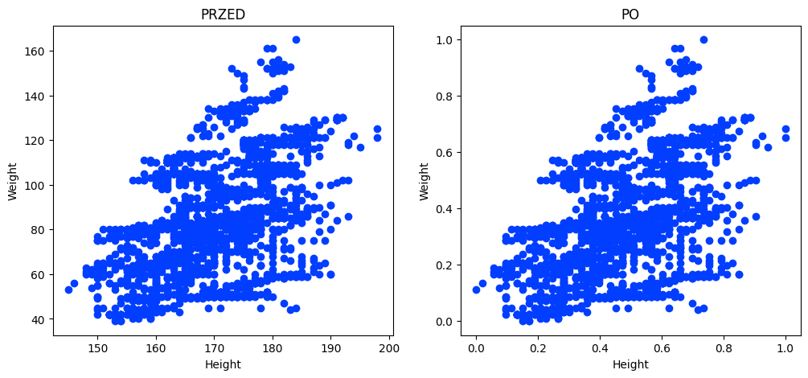

```python
fig, (ax1, ax2) = plt.subplots(ncols=2, figsize=(12,5))

ax1.scatter(DF.Height, DF.Weight)
ax1.set_title('PRZED')
ax1.set_ylabel('Weight')
ax1.set_xlabel('Height');

ax2.scatter(X.Height, X.Weight)
ax2.set_title('PO')
ax2.set_ylabel('Weight')
ax2.set_xlabel('Height')
```

## Metoda łokcia oraz Wskaznika Silhouette

> Podobnie jak w pracy "Analiza skupień w piłce nożnej" M.Kędra zastosowaliśmy metodę łokcia oraz profilu, aby znaleść liczbę klastrów.

```python
X_km = X[['Age', 'Height', 'Weight', 'family_history_with_overweight', 'Gender']]
```

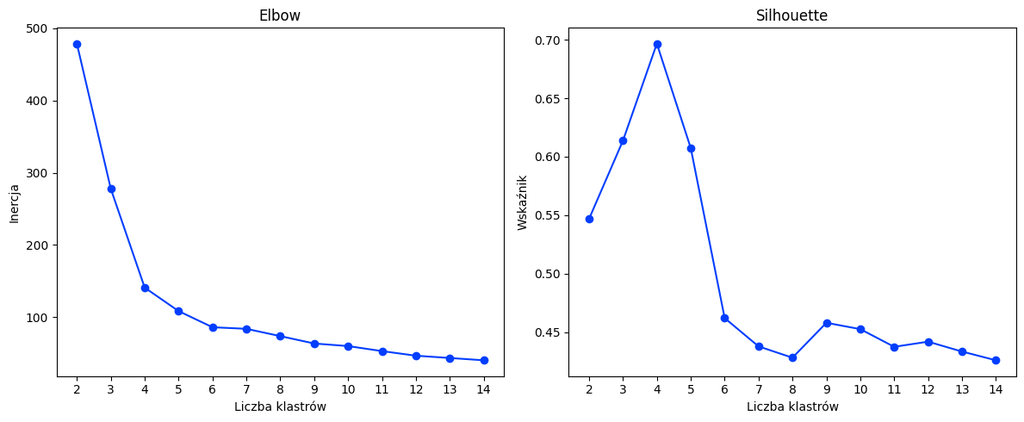

```python
inertia = []
silhouette_scores = []
k_range = range(2, 15)
for k in k_range:
    kmeans = KMeans(n_clusters=k, random_state=42)
    kmeans.fit(X_km)

    inertia_value = kmeans.inertia_
    inertia.append(inertia_value)

    silhouette_avg = silhouette_score(X_km, kmeans.labels_)
    silhouette_scores.append(silhouette_avg)

plt.figure(figsize=(12, 5))
plt.subplot(1, 2, 1)
plt.plot(k_range, inertia, marker='o')
plt.title('Elbow')
plt.xlabel('Liczba klastrów')
plt.ylabel('Inercja')
plt.xticks(k_range)

plt.subplot(1, 2, 2)
plt.plot(k_range, silhouette_scores, marker='o')
plt.title('Silhouette')
plt.xlabel('Liczba klastrów')
plt.ylabel('Wskaźnik')
plt.xticks(k_range)

plt.tight_layout()
plt.show()
```

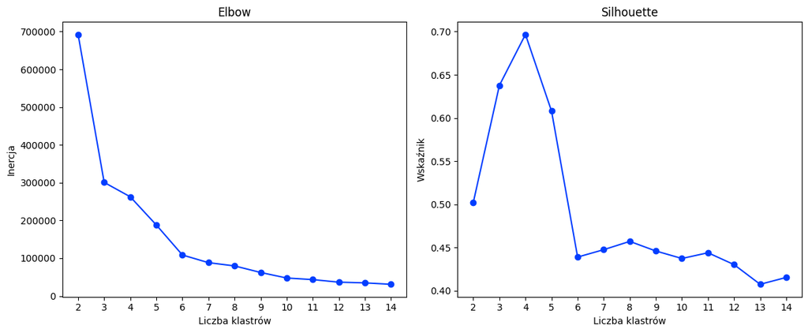

```python
inertia = []
silhouette_scores = []
k_range = range(2, 15)

for k in k_range:
    ward = AgglomerativeClustering(n_clusters=k, linkage='ward')
    labels = ward.fit_predict(X_km)

    inertia_value = sum((pairwise_distances(X_km[labels == i]).sum() for i in range(k))) / 2
    inertia.append(inertia_value)

    silhouette_avg = silhouette_score(X_km, labels)
    silhouette_scores.append(silhouette_avg)

plt.figure(figsize=(12, 5))

plt.subplot(1, 2, 1)
plt.plot(k_range, inertia, marker='o')
plt.title('Elbow')
plt.xlabel('Liczba klastrów')
plt.ylabel('Inercja')
plt.xticks(k_range)

plt.subplot(1, 2, 2)
plt.plot(k_range, silhouette_scores, marker='o')
plt.title('Silhouette')
plt.xlabel('Liczba klastrów')
plt.ylabel('Wskaźnik')
plt.xticks(k_range)

plt.tight_layout()
plt.show()
```

Za pomocą metody "łokcia" oraz wskaźnika Silhouette zdecydowalismy na optymalną liczbę klastrów na poziomie 4 klastrów

```
K-Means Silhouette Score: 0.70
Ward Silhouette Score: 0.70
Adjusted Rand Index (ARI) between K-Means and Ward clusters: 1.00
```

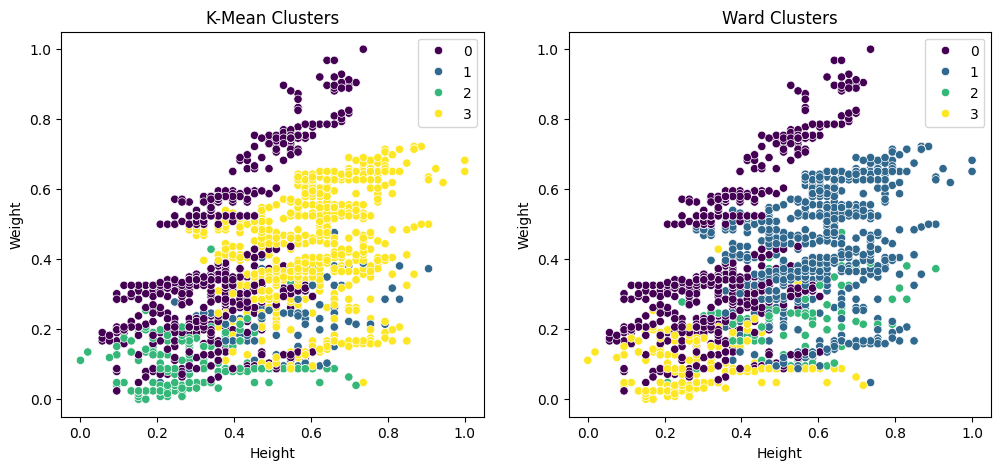

```python
kmeans = KMeans(n_clusters=4, random_state=42)
kmeans_labels = kmeans.fit_predict(X_km)

ward = AgglomerativeClustering(n_clusters=4, linkage='ward')
ward_labels = ward.fit_predict(X_km)

kmeans_silhouette = silhouette_score(X_km, kmeans_labels)
ward_silhouette = silhouette_score(X_km, ward_labels)
print(f"K-Means Silhouette Score: {kmeans_silhouette:.2f}")
print(f"Ward Silhouette Score: {ward_silhouette:.2f}")

ari_score = adjusted_rand_score(kmeans_labels, ward_labels)
print(f"Adjusted Rand Index (ARI) between K-Means and Ward clusters: {ari_score:.2f}")

plt.figure(figsize=(12, 5))

plt.subplot(1, 2, 1)
sns.scatterplot(x=X_km['Height'], y=X_km['Weight'], hue=kmeans_labels, palette='viridis')
plt.title("K-Mean Clusters")

plt.subplot(1, 2, 2)
sns.scatterplot(x=X_km['Height'], y=X_km['Weight'], hue=ward_labels, palette='viridis')
plt.title("Ward Clusters")

plt.show()
```

Metoda k-średnich oraz metoda Warda dały takie same wskaźniki Silhouette na poziomie 0.70. Oznacza to ,że obie metody są tak samo dobre.

```python
X_km['cluster'] = kmeans_labels
cluster_summary = X_km.groupby(X_km['cluster']).mean()
print("Statystyki średnie dla każdego klastra:")
print(cluster_summary)
```

```
Statystyki średnie dla każdego klastra:
              Age    Height    Weight  family_history_with_overweight  Gender
cluster
0        0.232049  0.383640  0.413609                             1.0     0.0
1        0.183424  0.510790  0.249663                             0.0     1.0
2        0.145635  0.297983  0.099514                             0.0     0.0
3        0.233274  0.594092  0.437064                             1.0     1.0
```

```python
X_km['cluster_ward'] = ward_labels
cluster_summary = X_km.groupby(X_km['cluster_ward']).mean()
print("Statystyki średnie dla każdego klastra:")
print(cluster_summary)
```

```
Statystyki średnie dla każdego klastra:
                   Age    Height    Weight  family_history_with_overweight  \
cluster_ward
0             0.232049  0.383640  0.413609                             1.0
1             0.233274  0.594092  0.437064                             1.0
2             0.183424  0.510790  0.249663                             0.0
3             0.145635  0.297983  0.099514                             0.0

              Gender  cluster
cluster_ward
0                0.0      0.0
1                1.0      3.0
2                1.0      1.0
3                0.0      2.0
```

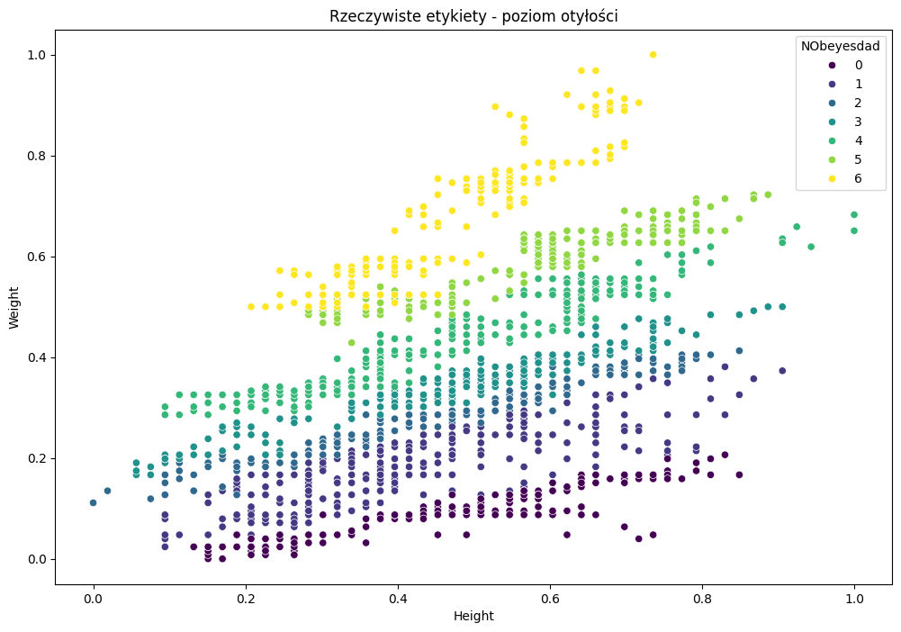

```python
plt.figure(figsize=(12, 8))
sns.scatterplot(x=X_km['Height'], y=X_km['Weight'], hue=y, palette='viridis')
plt.title("Rzeczywiste etykiety - poziom otyłości")
plt.show()
```

```python
X_km['Obesity'] = y
X_km.head()
```

|  | Age | Height | Weight | family_history_with_overweight | Gender | cluster | cluster_ward | Obesity |
| --- | --- | --- | --- | --- | --- | --- | --- | --- |
| 0 | 0.148936 | 0.320755 | 0.198413 | 1.0 | 0.0 | 0 | 0 | 1 |
| 1 | 0.148936 | 0.132075 | 0.134921 | 1.0 | 0.0 | 0 | 0 | 1 |
| 2 | 0.191489 | 0.660377 | 0.301587 | 1.0 | 1.0 | 3 | 1 | 1 |
| 3 | 0.276596 | 0.660377 | 0.380952 | 0.0 | 1.0 | 1 | 2 | 2 |
| 4 | 0.170213 | 0.622642 | 0.404762 | 0.0 | 1.0 | 1 | 2 | 3 |

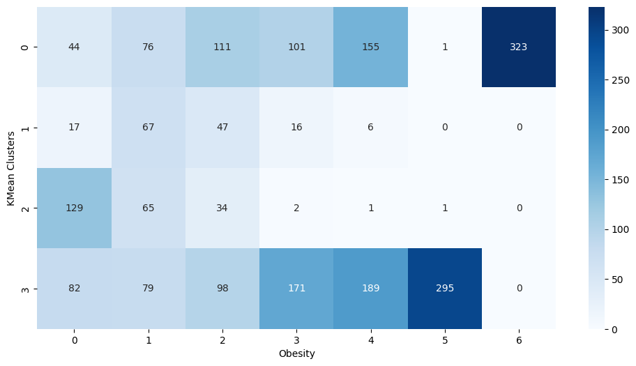

```python
table=X_km.groupby(['cluster', 'Obesity']).size().unstack(fill_value=0)
plt.figure(figsize=(12, 6))
sns.heatmap(table, annot=True, fmt='d', cmap='Blues')
plt.xlabel('Obesity')
plt.ylabel('KMean Clusters')
plt.show()
```

Powyższa ilsutracja pokazuje macierz trafień dla metody k-średnich.

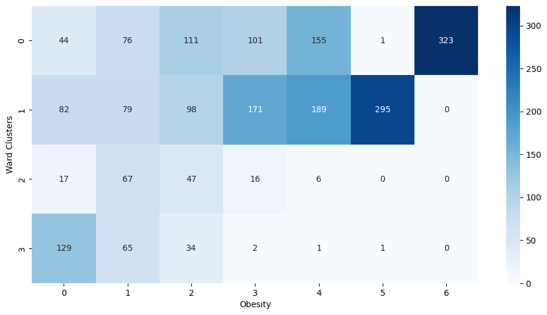

```python
table2=X_km.groupby(['cluster_ward', 'Obesity']).size().unstack(fill_value=0)
plt.figure(figsize=(12, 6))
sns.heatmap(table2, annot=True, fmt='d', cmap='Blues')
plt.xlabel('Obesity')
plt.ylabel('Ward Clusters')
plt.show()
```

Powyższa ilsutracja pokazuje macierz trafień dla metody Warda.

# Podsumowanie:

Wyniki te mogą być przydatne dla zdrowia publicznego, dostarczając informacji potrzebnych do projektowania strategii prewencyjnych i edukacyjnych. Grupy, które wykazały większe ryzyko otyłości, mogą stać się obiektem bardziej ukierunkowanych działań profilaktycznych, opartych na ich specyficznych potrzebach. Badanie stanowi również wartościowy przykład użycia algorytmów uczenia maszynowego do analizy zjawisk społecznych i zdrowotnych, pokazując, jak metody analizy danych mogą wspierać inicjatywy prozdrowotne.

# Bibliografia:

1. Wykłady "Wielowymiarowa Analiza Danych" dr hab. Konrad Furmańczyk, prof. SGGW
2. Wikipedia metoda k-średnich: https://en.wikipedia.org/wiki/K-means_clustering
3. Wikipedia metoda warda: https://pl.wikipedia.org/wiki/Metoda_Warda
4. WHO - Strategie w zakresie otyłości: https://www.who.int/news-room/fact-sheets/detail/obesity-and-overweight
5. Wikipedia Metoda Silhouette https://en.wikipedia.org/wiki/Silhouette_(clustering)
6. Wikipedia analiza skupień https://en.wikipedia.org/wiki/Cluster_analysis#Evaluation_and_assessment
7. clvalid an r package for cluster validation https://cran.r-project.org/web/packages/clValid/vignettes/clValid.pdf